# Week 3 NYPD data

2022-03-16

## Set up

Add the libraries that you will need for functions within the code. Note that these libraries will need to be installed, if not already. The installs are not recommended to be included within the R Markdown.

## Read in the dataset

The data is from the City of New York’s historical archives of Shootings recorded by the NYPD. This data set contains history of incidents and murders going back a few years by location and demographics.

```r
url_in <- "https://data.cityofnewyork.us/api/views/833y-fsy8/rows.csv?accessType=DOWNLOAD"
basedata <- read_csv(url_in)
```

## View the data set. I am interested in looking at the yearly trend of incidents and murders and also by Victim sex.

```r
summary(basedata)
```

```
##   INCIDENT_KEY        OCCUR_DATE         OCCUR_TIME           BORO
##  Min.   :  9953245   Length:23585       Length:23585      Length:23585
##  1st Qu.: 55322804   Class :character   Class1:hms        Class :character
##  Median : 83435362   Mode  :character   Class2:difftime   Mode  :character
##  Mean   :102280741                      Mode  :numeric
##  3rd Qu.:150911774
##  Max.   :230611229
##
##     PRECINCT      JURISDICTION_CODE LOCATION_DESC      STATISTICAL_MURDER_FLAG
##  Min.   :  1.00   Min.   :0.000     Length:23585       Mode :logical
##  1st Qu.: 44.00   1st Qu.:0.000     Class :character   FALSE:19085
##  Median : 69.00   Median :0.000     Mode  :character   TRUE :4500
##  Mean   : 66.21   Mean   :0.333
##  3rd Qu.: 81.00   3rd Qu.:0.000
##  Max.   :123.00   Max.   :2.000
##                   NA's   :2
##  PERP_AGE_GROUP       PERP_SEX          PERP_RACE         VIC_AGE_GROUP
##  Length:23585       Length:23585       Length:23585       Length:23585
##  Class :character   Class :character   Class :character   Class :character
##  Mode  :character   Mode  :character   Mode  :character   Mode  :character
##
##
##
##
##    VIC_SEX            VIC_RACE           X_COORD_CD        Y_COORD_CD
##  Length:23585       Length:23585       Min.   : 914928   Min.   :125757
##  Class :character   Class :character   1st Qu.: 999925   1st Qu.:182539
##  Mode  :character   Mode  :character   Median :1007654   Median :193470
##                                        Mean   :1009379   Mean   :207300
##                                        3rd Qu.:1016782   3rd Qu.:239163
##                                        Max.   :1066815   Max.   :271128
##
##     Latitude       Longitude        Lon_Lat
##  Min.   :40.51   Min.   :-74.25   Length:23585
##  1st Qu.:40.67   1st Qu.:-73.94   Class :character
##  Median :40.70   Median :-73.92   Mode  :character
##  Mean   :40.74   Mean   :-73.91
##  3rd Qu.:40.82   3rd Qu.:-73.88
##  Max.   :40.91   Max.   :-73.70
##
```

## Tidy the data set

Change the Occur date to date format. Then add a new variable Year.

```r
basedata <- basedata %>%
    mutate(OCCUR_DATE = mdy(OCCUR_DATE))

basedata <- basedata %>%
    mutate(YEAR = year(OCCUR_DATE))
```

View a Summary of the base data to see what kind of values are in the remaining fields that aren’t visible on the screen

```r
summary(basedata)
```

```
##   INCIDENT_KEY         OCCUR_DATE          OCCUR_TIME           BORO
##  Min.   :  9953245   Min.   :2006-01-01   Length:23585      Length:23585
##  1st Qu.: 55322804   1st Qu.:2008-12-31   Class1:hms        Class :character
##  Median : 83435362   Median :2012-02-27   Class2:difftime   Mode  :character
##  Mean   :102280741   Mean   :2012-10-05   Mode  :numeric
##  3rd Qu.:150911774   3rd Qu.:2016-03-02
##  Max.   :230611229   Max.   :2020-12-31
##
##     PRECINCT      JURISDICTION_CODE LOCATION_DESC      STATISTICAL_MURDER_FLAG
##  Min.   :  1.00   Min.   :0.000     Length:23585       Mode :logical
##  1st Qu.: 44.00   1st Qu.:0.000     Class :character   FALSE:19085
##  Median : 69.00   Median :0.000     Mode  :character   TRUE :4500
##  Mean   : 66.21   Mean   :0.333
##  3rd Qu.: 81.00   3rd Qu.:0.000
##  Max.   :123.00   Max.   :2.000
##                   NA's   :2
##  PERP_AGE_GROUP       PERP_SEX          PERP_RACE         VIC_AGE_GROUP
##  Length:23585       Length:23585       Length:23585       Length:23585
##  Class :character   Class :character   Class :character   Class :character
##  Mode  :character   Mode  :character   Mode  :character   Mode  :character
##
##
##
##
##    VIC_SEX            VIC_RACE           X_COORD_CD        Y_COORD_CD
##  Length:23585       Length:23585       Min.   : 914928   Min.   :125757
##  Class :character   Class :character   1st Qu.: 999925   1st Qu.:182539
##  Mode  :character   Mode  :character   Median :1007654   Median :193470
##                                        Mean   :1009379   Mean   :207300
##                                        3rd Qu.:1016782   3rd Qu.:239163
##                                        Max.   :1066815   Max.   :271128
##
##     Latitude       Longitude        Lon_Lat               YEAR
##  Min.   :40.51   Min.   :-74.25   Length:23585       Min.   :2006
##  1st Qu.:40.67   1st Qu.:-73.94   Class :character   1st Qu.:2008
##  Median :40.70   Median :-73.92   Mode  :character   Median :2012
##  Mean   :40.74   Mean   :-73.91                      Mean   :2012
##  3rd Qu.:40.82   3rd Qu.:-73.88                      3rd Qu.:2016
##  Max.   :40.91   Max.   :-73.70                      Max.   :2020
##
```

## Visualize the data

Visualize the trend of shootings (both Murders and incidents individually) by year

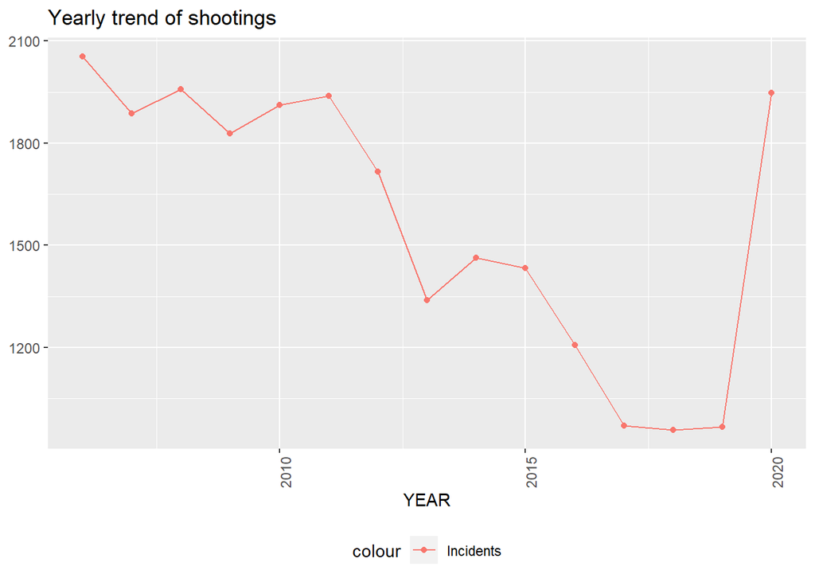

```r
summary_by_year <- basedata %>%
  count(YEAR)

summary_by_year <- summary_by_year %>%
  mutate(Incidents = n)

ggplot1 <- summary_by_year %>%
  ggplot(aes(x=YEAR, y = Incidents)) +
  geom_line(aes(color = "Incidents")) +
  geom_point(aes(color = "Incidents")) +
  theme(legend.position = "bottom",
        axis.text.x = element_text(angle= 90)) +
  labs(title = "Yearly trend of shootings", y = NULL)

plot(ggplot1)
```

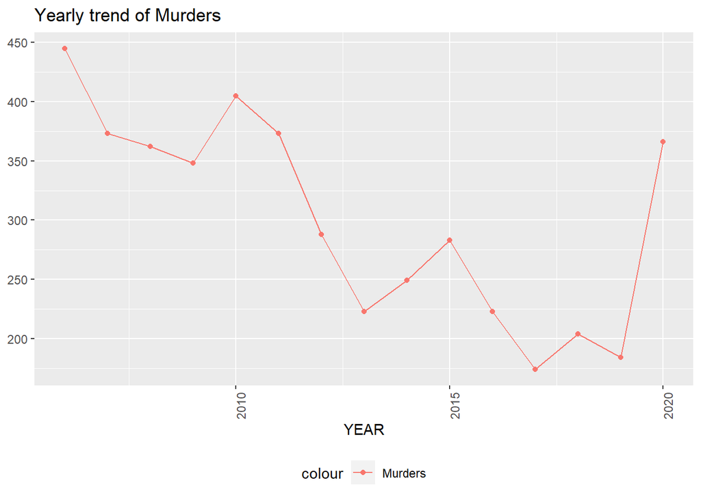

```r
  Murders_by_year <- basedata %>%
  filter(STATISTICAL_MURDER_FLAG == 'TRUE') %>%
  count(YEAR)



Murders_by_year <- Murders_by_year %>%
  mutate(Murders = n)

ggplot2 <- Murders_by_year %>%
  ggplot(aes(x=YEAR, y = Murders)) +
  geom_line(aes(color = "Murders")) +
  geom_point(aes(color = "Murders")) +
  theme(legend.position = "bottom",
        axis.text.x = element_text(angle= 90)) +
  labs(title = "Yearly trend of Murders", y = NULL)

plot(ggplot2)
```

### Recognizing and accounting for Bias. My Bias - There were probably more Female victims than Male victims

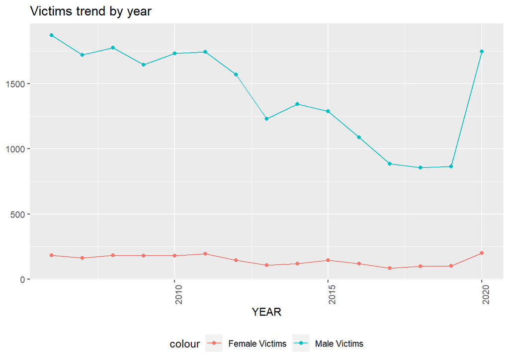

```r
Victims_Summary_Male <- basedata %>%
  filter(VIC_SEX == 'M') %>%
  count(YEAR)

Victims_Summary_Male <- Victims_Summary_Male %>%
  mutate(Male_victims = n)

Victims_Summary_Female <- basedata %>%
  filter(VIC_SEX == 'F') %>%
  count(YEAR)

Victims_Summary_Female <- Victims_Summary_Female %>%
  mutate(Female_victims = n)

Victims_Summary <- Victims_Summary_Female %>%
  left_join(Victims_Summary_Male, by = c("YEAR"))


ggplot3 <- Victims_Summary %>%
  ggplot(aes(x=YEAR, y = Male_victims)) +
  geom_line(aes(color = "Male Victims")) +
  geom_point(aes(color = "Male Victims")) +
  geom_line(aes(y = Female_victims, color = "Female Victims")) +
  geom_point(aes(y = Female_victims, color = "Female Victims")) +
  theme(legend.position = "bottom",
        axis.text.x = element_text(angle= 90)) +
  labs(title = "Victims trend by year", y = NULL)

plot(ggplot3)
```

## The above observation clearly shows that the bias of assuming there are more female victims than males is wrong.

## Model Data

### Linear Model to determine whether or how the Murders are related to Incidents. Predict Murders based on this model and compare with the actuals

```r
Incidents_and_Murders <- summary_by_year %>%
  left_join(Murders_by_year, by = c("YEAR"))

mod <- lm(Murders ~ Incidents, data = Incidents_and_Murders)
summary(mod)
```

```
##
## Call:
## lm(formula = Murders ~ Incidents, data = Incidents_and_Murders)
##
## Residuals:
##     Min      1Q  Median      3Q     Max
## -42.010 -15.070  -1.422  10.634  44.875
##
## Coefficients:
##              Estimate Std. Error t value Pr(>|t|)
## (Intercept) -26.16775   27.23773  -0.961    0.354
## Incidents     0.20744    0.01681  12.338  1.5e-08 ***
## ---
## Signif. codes:  0 '***' 0.001 '**' 0.01 '*' 0.05 '.' 0.1 ' ' 1
##
## Residual standard error: 25.41 on 13 degrees of freedom
## Multiple R-squared:  0.9213, Adjusted R-squared:  0.9153
## F-statistic: 152.2 on 1 and 13 DF,  p-value: 1.497e-08
```

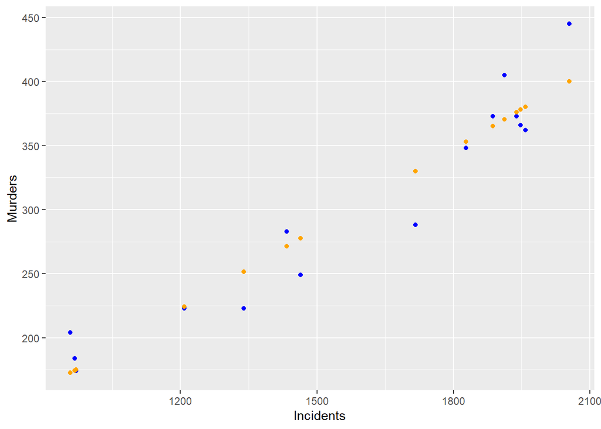

```r
Incidents_and_Murders <- Incidents_and_Murders %>%
  mutate(pred = predict(mod))

ggplot4 <- Incidents_and_Murders %>%
  ggplot() +
  geom_point(aes(x= Incidents, y= Murders), color= "blue") +
  geom_point(aes(x= Incidents, y= pred), color= "orange")

plot(ggplot4)
```

### The conclusion: The number of murders is linearly dependent on the number of total incidents. Bias based on victims gender is incorrect.